# Clustering

Victoria Zaitceva

2024-10-20

*Кластеризация* - разбиение наблюдений на подмножества (кластеры) таким образом, чтобы наблюдения из одного кластера были более похожи друг на друга, чем на наблюдения из других кластеров по какому-либо критерию.

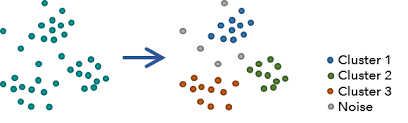

cl

Кластеризация относится к моделям обучения без учителя. Т.е. мы можем либо не знать сколько у нас получится кластеров по итогам, либо (в ряде подметодов) контролировать их количество вручную:

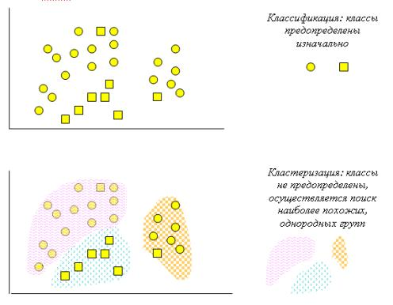

Прежде чем начать, отметим ряд особенностей кластеризации:

Не существует универсального алгоритма кластеризации. Алгоритмов достаточно много. Сегодня мы расммотрим четыре самых популярных из них; Нужно быть осторожным с интерпретацией кластерного анализа - далеко не всегда можно искренне считать, что получившиеся кластеры отражают структуру данных; Данные должны быть нормированы Отдельные кластеры можно выбраковывать Cостав и количество кластеров зависит от выбираемых переменных. Изменение переменных влияет на кластеры Данные о кластеризации полезны, если вы после успешной кластеризации будете присваивать данным переменную с номером кластера и работать с ней дальше при анализе.

/

Работать будем с данными двумя датасетами. Учебным датасет ирисов Фишера и реальными данными о страновых показателях [систем здравоохранения](https://www.kaggle.com/datasets/danevans/world-bank-wdi-212-health-systems).И в том и в другом случае мы будем наблюдать достаточно выраженные кластеры (что бывает далеко не всегда).

```r
# Ирисы
iris <- iris |>
  select(is.numeric)
# Системы здравоохранения
hs <- read.csv('data/Health_systems.csv')
rownames(hs) <- hs$World_Bank_Name

# Уберём дамми переменные и переменную с большим количеством миссингов. Оставим только полностью заполненные строки
hs_num <- hs |>
  select(-c(Country_Region, Province_State, World_Bank_Name, `Completeness_of_death_reg_2008.16`)) |>
  na.omit()

# Стандартизируем объекты для подсчёта и переведём их матрицу
iris_scaled <- scale(iris)
hs_scaled <- scale(hs_num)
```

# Иерархическая кластеризация (hierarchical clustering)

В основном к ней относится два вида алгоритмов:

*Agglomerative Nesting (agnes)* - каждое наблюдение находит ближайшее себе по дистанции до него (по каждой из переменных). После нахождения первого соседа, начинатся следующий шаг, когда образовавшийся мини-кластер ищет другие ближайшие к ним кластеры/наблюдения. Так прохожит несколько шагов, пока все наблюдения не сольются в один кластер.

*Divisive Analysis Clustering (diana)* - обратный способ. Мы отталкиваемся от одного кластера всех наблюдений и ищем непохожие друг на друга наблюдения и делим один кластер на два. Затем алгоритм продолжается до конца.

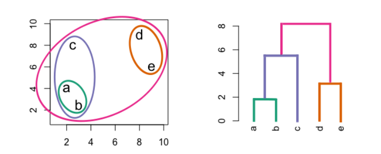

“Длинна” дистанции обозначает меру схожести/разницы наблюдений - Высоту/Height (Крестовский остров ближе к Институт биоинформатики чем к Кудрово).

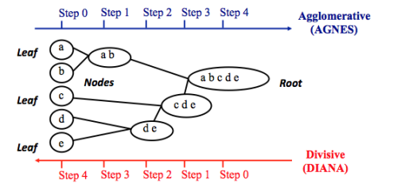

cl

Мы будем рассматривать agnes.

### Типы дистанций:

euclidian - если признаки числовые, одинаково важны и в похожих шкалах manhattan - для нелинейных связей, когда шкалы переменных сильно различаются и когда много выбросов cosine - для дамми переменных (0,1) и когда важна не велечина признаков, а их соотношение gower - для смешанных переменных

## 1. Создаем матрицу дистанций

```r
hs_dist <- dist(hs_scaled,
                method = "euclidean") # default

as.matrix(hs_dist)[1:6, 1:6]
```

```
##             Afghanistan  Albania  Algeria Argentina  Armenia Australia
## Afghanistan    0.000000 3.631491 4.844901  5.995297 4.209154  7.496611
## Albania        3.631491 0.000000 1.862557  3.390808 3.043501  5.315160
## Algeria        4.844901 1.862557 0.000000  2.044730 4.217423  4.859874
## Argentina      5.995297 3.390808 2.044730  0.000000 4.458793  4.087963
## Armenia        4.209154 3.043501 4.217423  4.458793 0.000000  5.683430
## Australia      7.496611 5.315160 4.859874  4.087963 5.683430  0.000000
```

```r
iris_dist <- dist(iris_scaled,
                  method = "euclidean")
as.matrix(iris_dist)[1:6, 1:6]
```

```
##           1         2         3         4         5         6
## 1 0.0000000 1.1722914 0.8427840 1.0999999 0.2592702 1.0349769
## 2 1.1722914 0.0000000 0.5216255 0.4325508 1.3818560 2.1739229
## 3 0.8427840 0.5216255 0.0000000 0.2829432 0.9882608 1.8477070
## 4 1.0999999 0.4325508 0.2829432 0.0000000 1.2459861 2.0937597
## 5 0.2592702 1.3818560 0.9882608 1.2459861 0.0000000 0.8971079
## 6 1.0349769 2.1739229 1.8477070 2.0937597 0.8971079 0.0000000
```

## 2. Высчитываем дендограмму кластеров

Для иерахической кластеризации используется функция `hclust`

```r
hs_dist.hc <- hclust(hs_dist,
                     method = "ward.D2") # default
```

## 3. Визуализируем дендограмму

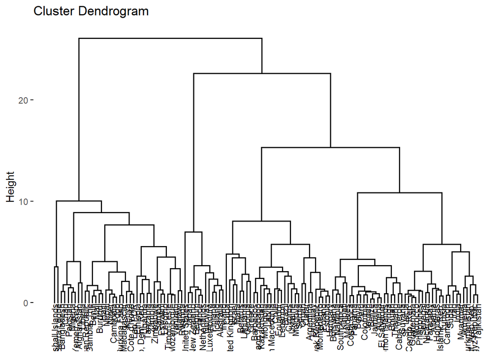

```r
fviz_dend(hs_dist.hc,
          cex = 0.6) # cex() - размер лейблов
```

```r
# we don't know the number of clusters yet
```

## 4. Работа с дендрограмой

```r
hs_dist.hc_k3 <- cutree(hs_dist.hc,
                          k = 3) # Создаём вектор принадлежности к кластерам. 3 - количество кластеров

# Смотрим результат - first 4 rows
head(hs_dist.hc_k3, n = 4)
```

```
## Afghanistan     Albania     Algeria   Argentina
##           1           2           2           2
```

```r
table(hs_dist.hc_k3)
```

```
## hs_dist.hc_k3
##  1  2  3
## 38 74 12
```

38 наблюдений (стран) вв первом кластере, 74 во втором и 12 в третьем

Можем установить линию тршэшхолда для кластеров вручную:

```r
hs_dist.hc_h20 <- cutree(hs_dist.hc, h=20)  # Создаём вектор принадлежности к кластерам. height = 20 - высота линии

# Смотрим результат
table(hs_dist.hc_h20)
```

```
## hs_dist.hc_h20
##  1  2  3
## 38 74 12
```

Визуализация

1 варинт

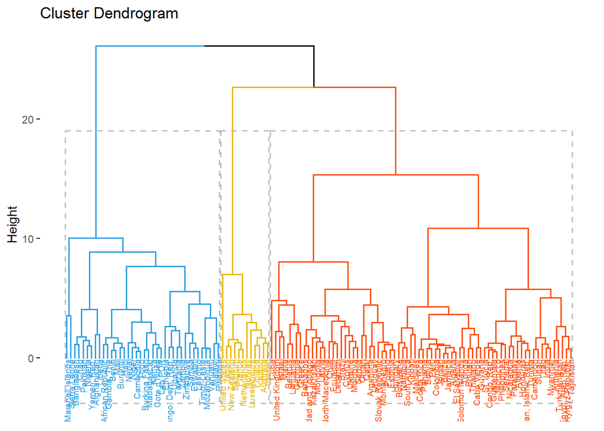

```r
fviz_dend(hs_dist.hc,
          k = 3, # Задаём число кластеров
          cex = 0.5, # Задаем размер лейблов
          k_colors = c("#2E9FDF", "#E7B800", "#FC4E07"),
          color_labels_by_k = TRUE, # Соотнести цвета с кластерами
          rect = TRUE # Добавить "квадратик" вокруг групп
)
```

2 вариант

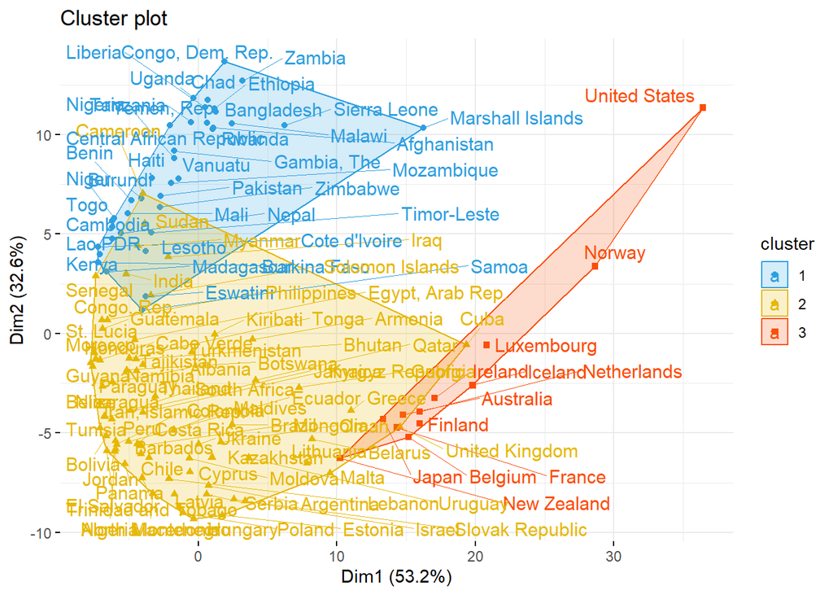

```r
fviz_cluster(list(data = hs_dist, cluster = hs_dist.hc_h20),
             palette = c("#2E9FDF", "#E7B800", "#FC4E07"),
             ellipse.type = "convex", # Объединить кластеры элипсом
             repel = TRUE, # Избежать наслоения лейблов
             show.clust.cent = FALSE, # Показывать центр кластера
             ggtheme = theme_minimal())
```

```r
# изменить на 5 случайных наблюдений из каждого кластера
```

3 вариант

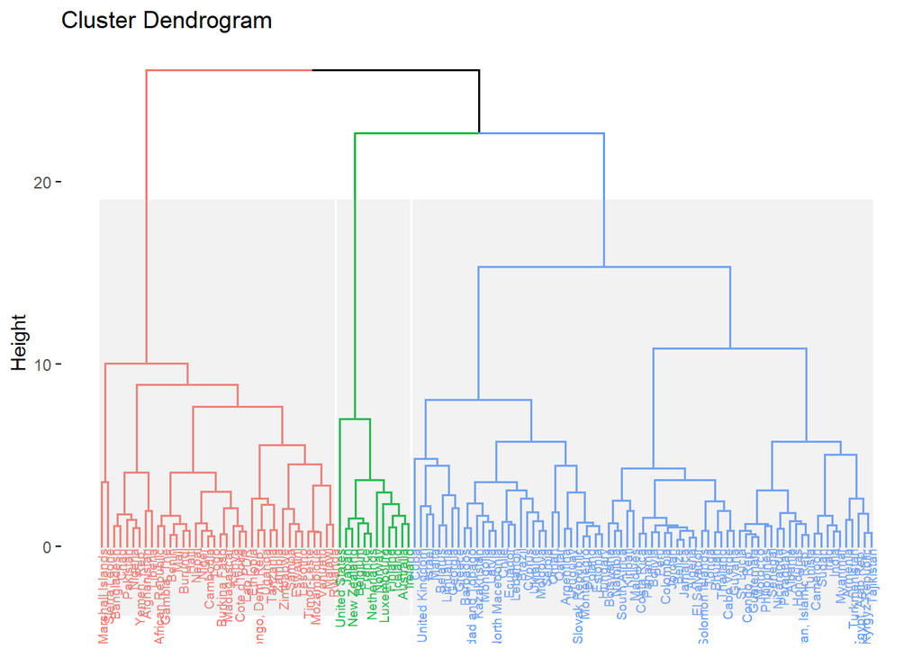

```r
fviz_dend(hs_dist.hc,
          k = 3,
          cex = 0.5,
          # k_colors = c("#2E9FDF", "#E7B800", "#FC4E07"),
          color_labels_by_k = TRUE,
          rect = TRUE,
          # rect_border = c("#2E9FDF", "#E7B800", "#FC4E07"), # Добавить цвет для границы "квадратика"
          rect_fill = TRUE) # Закрасить внутреннюю часть "квадратика"
```

4 вариант - горизонтальный

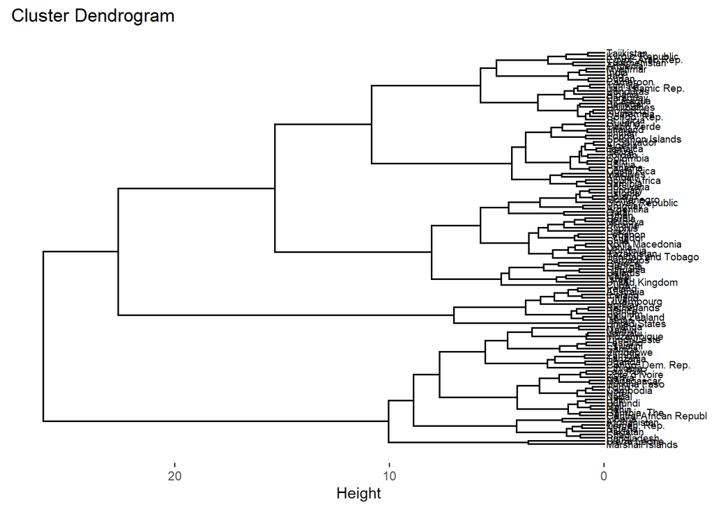

```r
fviz_dend(hs_dist.hc,
          cex = 0.5,
          horiz = TRUE)
```

```r
# расширить график чтобы подписи были более читабельными можно например при сохранении с ggsave
```

5 вариант - Раскрашиваем горизонтальную дендрограмму

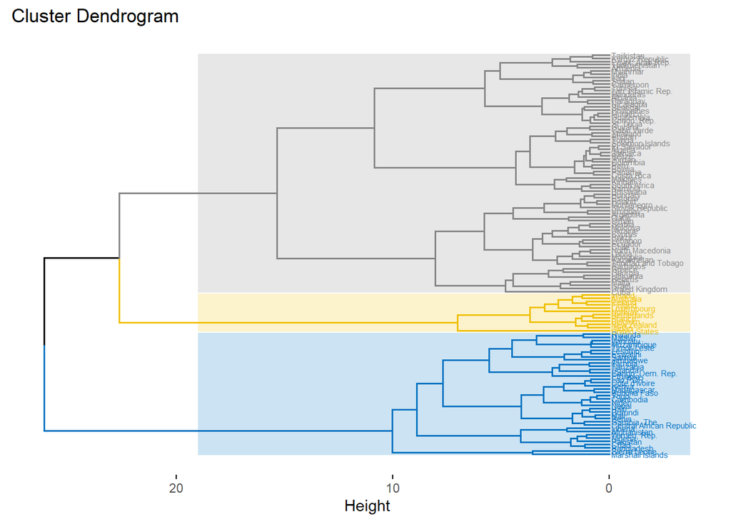

```r
fviz_dend(hs_dist.hc,
          k = 3,
          cex = 0.4,
          horiz = TRUE,
          k_colors = "jco",
          rect = TRUE,
          rect_border = "jco",
          rect_fill = TRUE)
```

6 варинт - круговая дендрограмма

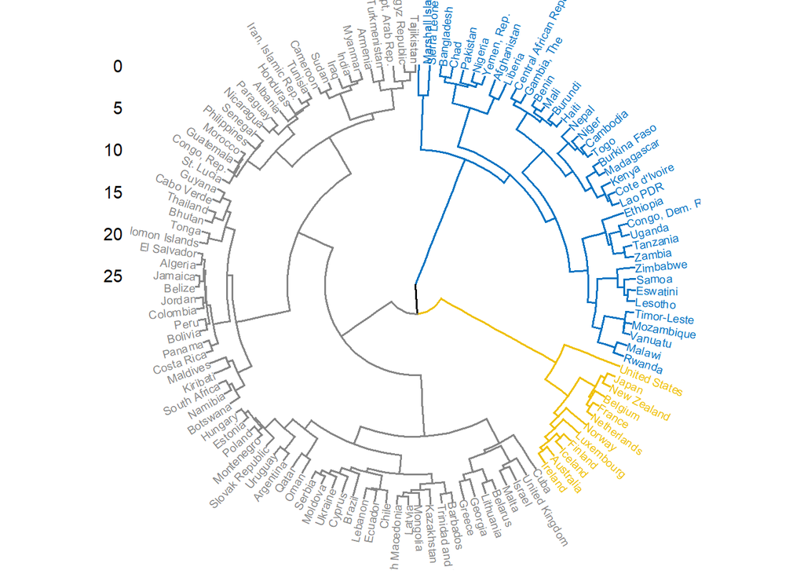

```r
fviz_dend(hs_dist.hc,
          cex = 0.5,
          k = 3,
          k_colors = "jco",
          type = "circular")
```

7 вариант - Древовидная дендрограмма

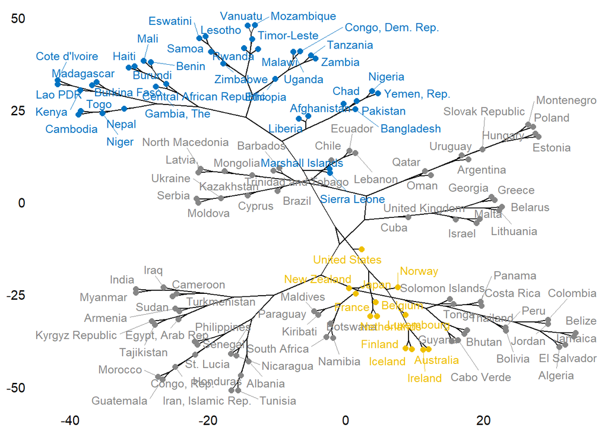

```r
fviz_dend(hs_dist.hc,
          k = 3,
          k_colors = "jco",
          type = "phylogenic",
          repel = TRUE) # Избежать наслоения лейблов
```

8 вариант - Приближение на участок дендрограммы

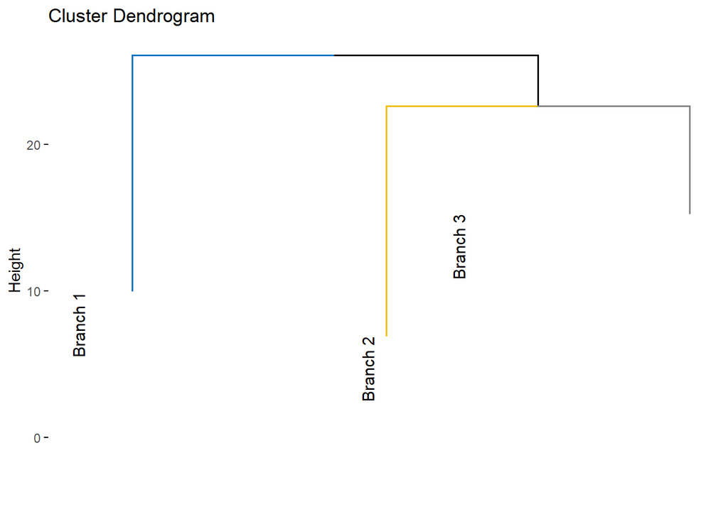

```r
hc_plot <- fviz_dend(hs_dist.hc,
                       k = 3,
                       cex = 0.5,
                       k_colors = "jco"
)
dend_data <- attr(hc_plot,
                  "dendrogram") # Извлекаем данные по дендрограмме

# Разрезаем по высоте h = 20
dend_cuts <- cut(dend_data, h = 20)
# Смотрим верхнюю часть графика
fviz_dend(dend_cuts$upper)
```

Нижнюю мы сразу посмотреть не можем, т.к. мы теперь имеем дело с 3 независимыми дендрограммами…

9 вариант - Выведение отдельной ветви дендрограммы

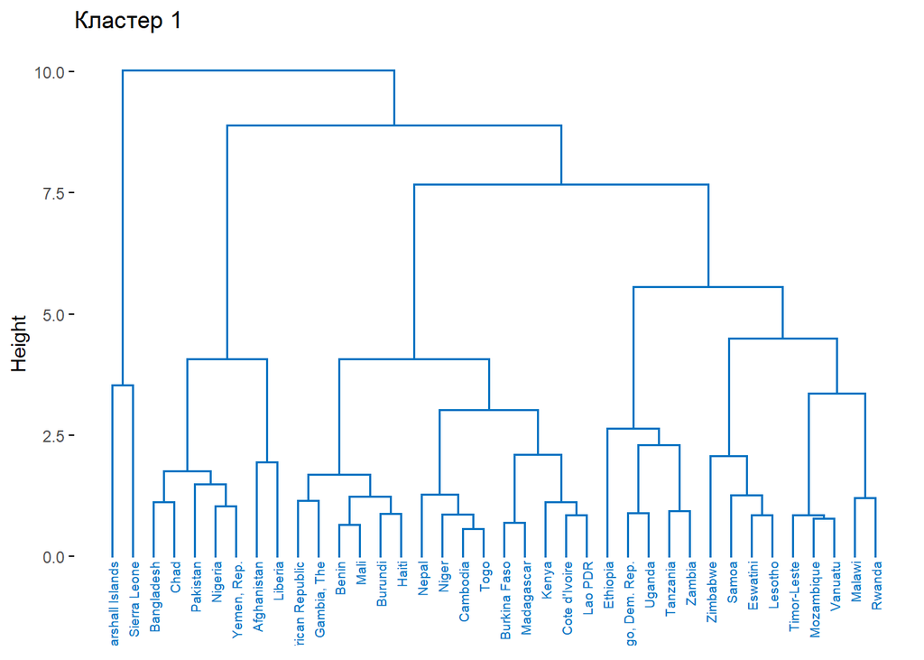

```r
fviz_dend(dend_cuts$lower[[1]],
          main = "Кластер 1")
```

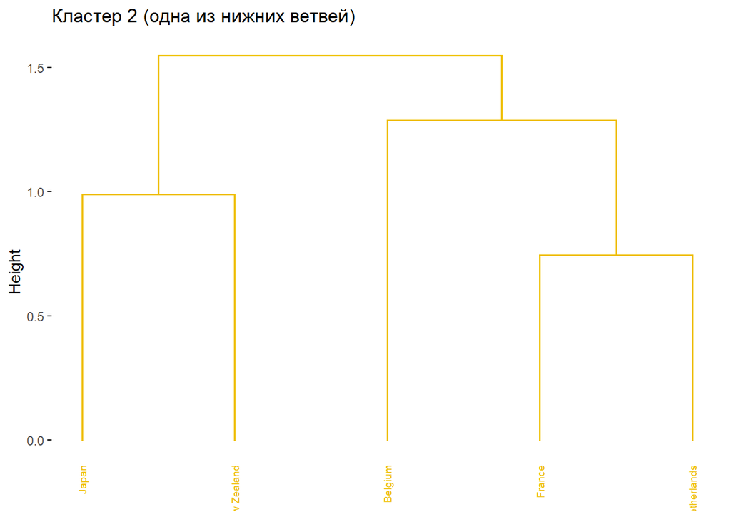

```r
# Plot subtree 2
fviz_dend(dend_cuts[["lower"]][[2]][[2]][[1]],
          main = "Кластер 2 (одна из нижних ветвей)")
```

Альтернативный способ анализа с помощью пакета cluster cluster представляет также представляет удобный функционал для работы с деревьями. Его пример ниже:

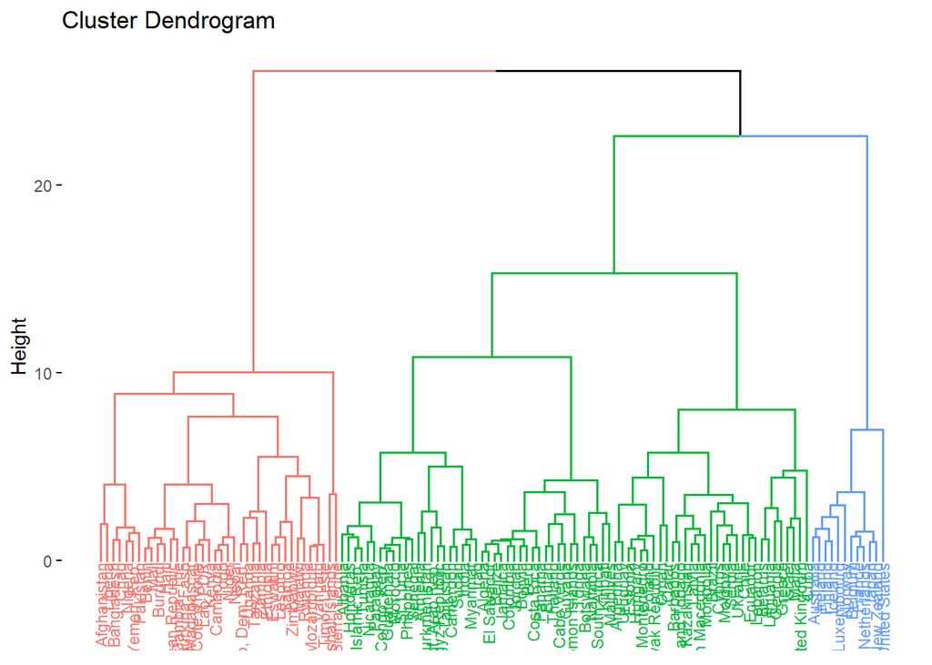

```r
library(cluster)
# Agnes
hs.agnes <- agnes(x = hs_dist,
                   stand = F, # Стандартизировать данные?
                   metric = "euclidean",
                   method = "ward" )

# Diana
hs.diana <- diana(x = hs_dist,
                   stand = F,
                   metric = "euclidean")

fviz_dend(hs.agnes, cex = 0.6, k = 3)
```

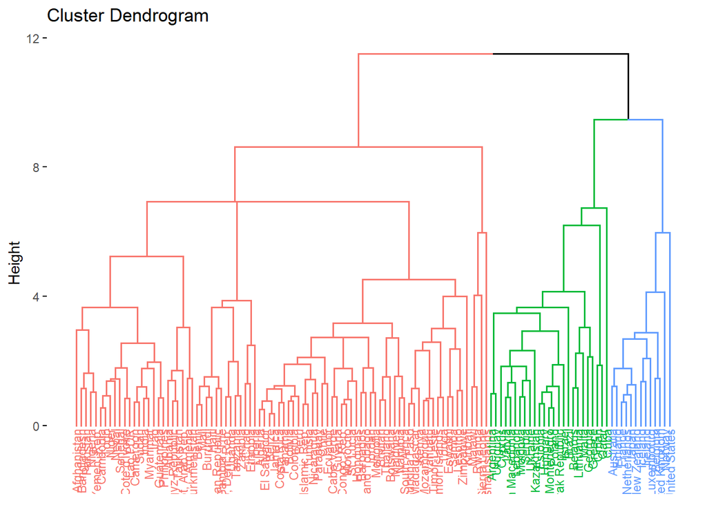

```r
fviz_dend(hs.diana, cex = 0.6, k = 3)
```

# Partitioning Clustering

## kMeans

*Общая идея:*

1. Случайным образом задаём n-ое количество точек. Число n выбираем сами (как это сделать - ниже). Эти точки называем центроидами - геометрическими центрами кластеров
2. Для всех точек-наблюдений определяем, к какому центроиду они ближе. Благодаря этому, мы образуем кластер вокруг центроида
3. Перемещаем каждый центроид в геометрический центр точек его кластера (изначально же наблюдения включались просто по факту того, что центроид был ближе, а не “центральнее”)
4. Пересчитываем точки, которые в таком, новом положении центроида попали в его кластер
5. Курсируем между шагом 3 и 4 до тех пор, пока в результате нового движения ни одна из точек не поменяет принадлежность к какому-либо кластеру

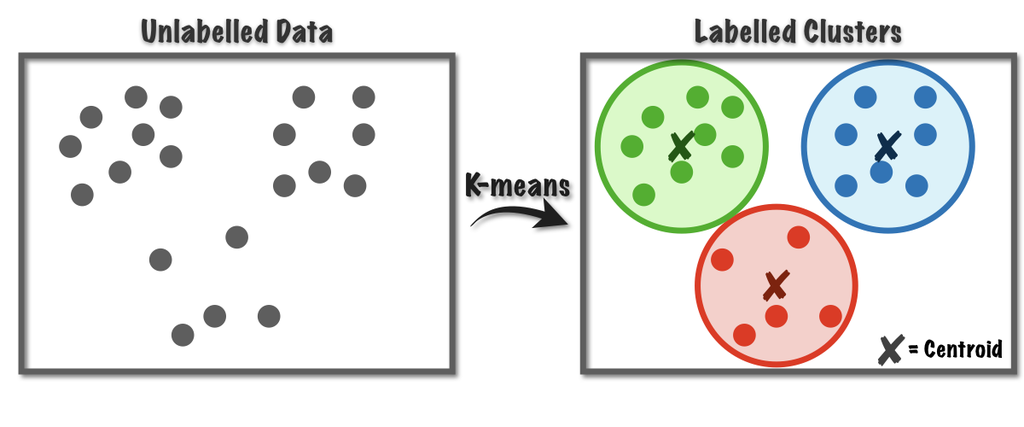

cl

Посмотрим движение центроида на [видео](https://www.youtube.com/watch?v=nXY6PxAaOk0)

…

А можно ли доверять такому способу кластеризации k-means?

Нет, всегда надо быть на чеку. Разберёмся почему на [этом сайте](https://www.naftaliharris.com/blog/visualizing-k-means-clustering/).

…

Считать kMeans просто:

```r
hs_kmean <- kmeans(hs_num,
                          centers = 3, # Количество центроидов-кластеров
                          iter.max = 10, # Максимальное количество итераций-шагов центроидов
                          nstart = 35) # Какое количество центроидов сгенерировать в начале? Потом автоматически алгоритм сократит их до числа centers, оставив только лучшие. Рекомендуется ставить между 25 и 50, чтобы найти стабильное решение

head(hs_kmean)
```

```
## $cluster
##              Afghanistan                  Albania                  Algeria
##                        2                        2                        2
##                Argentina                  Armenia                Australia
##                        3                        2                        1
##               Bangladesh                 Barbados                  Belarus
##                        2                        3                        2
##                  Belgium                   Belize                    Benin
##                        1                        2                        2
##                   Bhutan                  Bolivia                 Botswana
##                        2                        2                        2
##                   Brazil             Burkina Faso                  Burundi
##                        3                        2                        2
##               Cabo Verde                 Cambodia                 Cameroon
##                        2                        2                        2
## Central African Republic                     Chad                    Chile
##                        2                        2                        3
##                 Colombia         Congo, Dem. Rep.              Congo, Rep.
##                        2                        2                        2
##               Costa Rica            Cote d'Ivoire                     Cuba
##                        3                        2                        3
##                   Cyprus                  Ecuador         Egypt, Arab Rep.
##                        3                        2                        2
##              El Salvador                  Estonia                 Eswatini
##                        2                        3                        2
##                 Ethiopia                  Finland                   France
##                        2                        1                        1
##              Gambia, The                  Georgia                   Greece
##                        2                        2                        3
##                Guatemala                   Guyana                    Haiti
##                        2                        2                        2
##                 Honduras                  Hungary                  Iceland
##                        2                        3                        1
##                    India       Iran, Islamic Rep.                     Iraq
##                        2                        3                        2
##                  Ireland                   Israel                  Jamaica
##                        1                        3                        2
##                    Japan                   Jordan               Kazakhstan
##                        1                        2                        2
##                    Kenya                 Kiribati          Kyrgyz Republic
```

[output cut: 64 more lines]

```
## 1                             69.90769                         100.00000
## 2                             18.91477                          76.36818
## 3                             58.14348                          99.33913
##
## $totss
## [1] 667604995
##
## $withinss
## [1] 67336940 12948603 15728137
##
## $tot.withinss
## [1] 96013681
##
## $betweenss
## [1] 571591314
```